# PHOT 110: Introduction to programming

PHOT 110: Introduction to programming

LECTURE 05

Michaël Barbier

Version: April 19, 2026

## Program structures so far …

0. **Calculator**: Only expressions, re-use previous result, no re-running
1. Scripts: **variables & expressions**: re-run same script, track and remove human mistakes
2. Branching (**`if`**, **`else`**): explicit logical expressions, execute code according to decisions
3. **`while`** and **`for`** Loops: Repeat code, according to condition
4. **Functions**: further re-use, abstraction of code, call whenever required, allows parameters

## Functions

- are separate reusable pieces of code
- can be invoked or called from the script
- accept 0 or more parameters
- return an object(s) (possible `None`)

## Function definition syntax

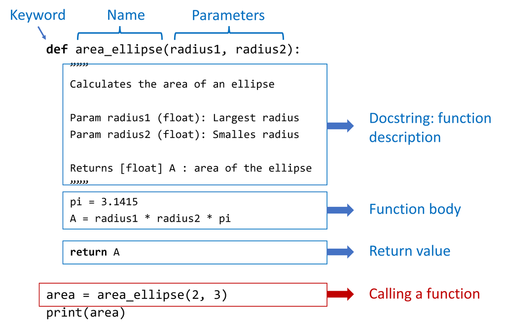

## Function declaration

```python
def area_ellipse(radius1, radius2):
  """
  area_ellipse calculates the area of an ellipse

  Param radius1 (float): Largest radius
  Param radius2 (float): Smalles radius

  Returns [float] A : area of the ellipse
  """
  pi = 3.1415
  A = radius1 * radius2 * pi

  return A

area = area_ellipse(2, 3)
print(f"The area of the ellipse is {area}")
```

```
The area of the ellipse is 18.849
```

## Return values

- Use the **`return`** keyword
- the value can be an expression
- Without **`return`**, function returns **`None`**
- Multiple outputs possible

```python
def add(a, b):
  """ Sum a and b """
  return a + b

sum = add(2, 5)
print(sum)
```

```
7
```

## Return values

- Use the **`return`** keyword

```python
def add(a, b):
  """ Sum a and b """
  sum = a + b
  return sum

sum = add(2, 5)
print(sum)
```

```
7
```

## Return values

- Use the **`return`** keyword
- the value can be an expression

```python
def add(a, b):
  """ Sum a and b """
  return a + b

sum = add(2, 5)
print(sum)
```

```
7
```

## Return values

- Use the **`return`** keyword
- the value can be an expression
- Without **`return`**, function returns **`None`**

```python
def add(a, b):
  """ Sum a and b """
  a + b

sum = add(2, 5)
print(sum)
```

```
None
```

## Return values

- Use the **`return`** keyword
- the value can be an expression
- Without **`return`**, function returns **`None`**
- Multiple outputs possible

```python
def add(a, b):
  """ Sum a and b and give extra outputs """
  return a + b, "a second output", a - b

out = add(2, 5)
print(out)
```

```
(7, 'a second output', -3)
```

## Unpacking multiple outputs

```python
import math

def polar_to_carth(radius, angle):
  """ polar_to_carth converts polar to carthesian """
  x = radius*math.cos(angle)
  y = radius*math.sin(angle)

  return x, y

x, y = polar_to_carth(3, math.pi/3)
print(f"Polar (3, pi/3) = {(x, y)}")
```

```
Polar (3, pi/3) = (1.5000000000000004, 2.598076211353316)
```

## Multiple return statements possible

```python
def minimum(a, b):
  """ Returns the minimum of two numbers """
  if a <= b:
    return a
  else:
    return b

print(minimum(3.4, 6.5))
```

```
3.4
```

## Variable scope

Script variables and function parameters can have the same name

```python
def increment(a):
  """ Increment number by 1 """
  a = a + 1
  return a

# Define the variable in the script
a = 5
print("Variable a (before) = " + str(a))
b = increment(a)
print("Variable a (after) = " + str(a))
print("Variable b = " + str(b))
```

```
Variable a (before) = 5
Variable a (after) = 5
Variable b = 6
```

## Variable scope

- Functions can use script variables from **outside** the function
- But **cannot** change those variables

```python
def increment(a):
  """ Increment number by 1 """
  a = a + x
  return a

# Define the variable in the script
a = 5
x = 4
print(increment(a))
```

```
9
```

## Variable scope

- Functions can use script variables from **outside** the function
- But **cannot** change those variables

```python
def increment(a):
  """ Increment number by 1 """
  a = a + x
  x = x + 3
  return a

# Define the variable in the script
a = 5
x = 4
print(increment(a))
```

```
---------------------------------------------------------------------------
UnboundLocalError                         Traceback (most recent call last)
Cell In[11], line 10
      8 a = 5
      9 x = 4
---> 10 print(increment(a))

Cell In[11], line 3, in increment(a)
      1 def increment(a):
      2   """ Increment number by 1 """
----> 3   a = a + x
      4   x = x + 3
      5   return a

UnboundLocalError: cannot access local variable 'x' where it is not associated with a value
```

## Functions can call functions

```python
def minimum(a, b):
  if a <= b:
    return a
  else:
    return b

def add(a, b, fct):
  """ Sum a, b and minimum of both """
  return a + b + fct(a, b)

a = 10; b = 2
print(add(a, b, minimum))
```

```
14
```